# Bellabeat Case Study

Jeong Park

2022-08-25

### **Statement of Business Task**:

Analyze user trends of one of Bellabeat’s products and the smart device data in order to gain actionable insight that could provide data-driven marketing strategies to unlock the potential growth of Bellabeat.

#### **Key stakeholders**:

Urška Sršen - Bellabeat’s Cofounder & CCO

Sando Mur - Mathematician and Bellabeat’s cofounder; key member of the Bellabeat executive team

Bellabeat marketing analytics team - A team of data analysts responsible for collecting, analyzing, and reporting data that helps guide Bellabeat’s marketing strategy.

#### **Questions for the analysis**:

What are some trends in smart device usage?

How could these trends apply to Bellabeat customers?

How could these trends help influence Bellabeat marketing strategy?

##### Installing and Loading Packages

```r
install.packages("tidyverse", quiet = T)
install.packages("skimr", quiet = T)
install.packages("janitor", quiet = T)
install.packages("dplyr", quiet = T)
install.packages("sqldf", quiet = T)
install.packages("reshape2", quiet = T)
library("tidyverse", quietly = T)
library("skimr", quietly = T)
library("janitor", quietly = T)
library("dplyr", quietly = T)
library("sqldf", quietly = T)
library("reshape2", quietly = T)
```

#### Importing Datasets

```r
setwd("/Users/Jeong Park/OneDrive/Documents/Fitabase Data 2016.04.12 - 2016.05.12")
daily_Activity <- read_csv("dailyActivity_merged.csv", show_col_types = FALSE)
daily_Calories <- read_csv("dailyCalories_merged.csv", show_col_types = FALSE)
daily_Intensities <- read_csv("dailyIntensities_merged.csv", show_col_types = FALSE)
daily_Steps <- read_csv("dailySteps_merged.csv", show_col_types = FALSE)
sleep_Day <- read_csv("sleepDay_merged.csv", show_col_types = FALSE)
weight_Loginfo <- read_csv("weightLogInfo_merged.csv", show_col_types = FALSE)
```

#### Observing the data

```r
head(daily_Activity)
```

```
## # A tibble: 6 x 15
##        Id ActivityDate TotalSteps TotalDistance TrackerDistance LoggedActivitie~
##     <dbl> <chr>             <dbl>         <dbl>           <dbl>            <dbl>
## 1  1.50e9 4/12/2016         13162          8.5             8.5                 0
## 2  1.50e9 4/13/2016         10735          6.97            6.97                0
## 3  1.50e9 4/14/2016         10460          6.74            6.74                0
## 4  1.50e9 4/15/2016          9762          6.28            6.28                0
## 5  1.50e9 4/16/2016         12669          8.16            8.16                0
## 6  1.50e9 4/17/2016          9705          6.48            6.48                0
## # ... with 9 more variables: VeryActiveDistance <dbl>,
## #   ModeratelyActiveDistance <dbl>, LightActiveDistance <dbl>,
## #   SedentaryActiveDistance <dbl>, VeryActiveMinutes <dbl>,
## #   FairlyActiveMinutes <dbl>, LightlyActiveMinutes <dbl>,
## #   SedentaryMinutes <dbl>, Calories <dbl>
```

```r
glimpse(daily_Activity)
```

```
## Rows: 940
## Columns: 15
## $ Id                       <dbl> 1503960366, 1503960366, 1503960366, 150396036~
## $ ActivityDate             <chr> "4/12/2016", "4/13/2016", "4/14/2016", "4/15/~
## $ TotalSteps               <dbl> 13162, 10735, 10460, 9762, 12669, 9705, 13019~
## $ TotalDistance            <dbl> 8.50, 6.97, 6.74, 6.28, 8.16, 6.48, 8.59, 9.8~
## $ TrackerDistance          <dbl> 8.50, 6.97, 6.74, 6.28, 8.16, 6.48, 8.59, 9.8~
## $ LoggedActivitiesDistance <dbl> 0, 0, 0, 0, 0, 0, 0, 0, 0, 0, 0, 0, 0, 0, 0, ~
## $ VeryActiveDistance       <dbl> 1.88, 1.57, 2.44, 2.14, 2.71, 3.19, 3.25, 3.5~
## $ ModeratelyActiveDistance <dbl> 0.55, 0.69, 0.40, 1.26, 0.41, 0.78, 0.64, 1.3~
## $ LightActiveDistance      <dbl> 6.06, 4.71, 3.91, 2.83, 5.04, 2.51, 4.71, 5.0~
## $ SedentaryActiveDistance  <dbl> 0, 0, 0, 0, 0, 0, 0, 0, 0, 0, 0, 0, 0, 0, 0, ~
## $ VeryActiveMinutes        <dbl> 25, 21, 30, 29, 36, 38, 42, 50, 28, 19, 66, 4~
## $ FairlyActiveMinutes      <dbl> 13, 19, 11, 34, 10, 20, 16, 31, 12, 8, 27, 21~
## $ LightlyActiveMinutes     <dbl> 328, 217, 181, 209, 221, 164, 233, 264, 205, ~
## $ SedentaryMinutes         <dbl> 728, 776, 1218, 726, 773, 539, 1149, 775, 818~
## $ Calories                 <dbl> 1985, 1797, 1776, 1745, 1863, 1728, 1921, 203~
```

```r
head(daily_Calories)
```

```
## # A tibble: 6 x 3
##           Id ActivityDay Calories
##        <dbl> <chr>          <dbl>
## 1 1503960366 4/12/2016       1985
## 2 1503960366 4/13/2016       1797
## 3 1503960366 4/14/2016       1776
## 4 1503960366 4/15/2016       1745
## 5 1503960366 4/16/2016       1863
## 6 1503960366 4/17/2016       1728
```

```r
glimpse(daily_Calories)
```

```
## Rows: 940
## Columns: 3
## $ Id          <dbl> 1503960366, 1503960366, 1503960366, 1503960366, 1503960366~
## $ ActivityDay <chr> "4/12/2016", "4/13/2016", "4/14/2016", "4/15/2016", "4/16/~
## $ Calories    <dbl> 1985, 1797, 1776, 1745, 1863, 1728, 1921, 2035, 1786, 1775~
```

```r
head(daily_Intensities)
```

```
## # A tibble: 6 x 10
##           Id ActivityDay SedentaryMinutes LightlyActiveMinutes FairlyActiveMinu~
##        <dbl> <chr>                  <dbl>                <dbl>             <dbl>
## 1 1503960366 4/12/2016                728                  328                13
## 2 1503960366 4/13/2016                776                  217                19
## 3 1503960366 4/14/2016               1218                  181                11
## 4 1503960366 4/15/2016                726                  209                34
## 5 1503960366 4/16/2016                773                  221                10
## 6 1503960366 4/17/2016                539                  164                20
## # ... with 5 more variables: VeryActiveMinutes <dbl>,
## #   SedentaryActiveDistance <dbl>, LightActiveDistance <dbl>,
## #   ModeratelyActiveDistance <dbl>, VeryActiveDistance <dbl>
```

```r
glimpse(daily_Intensities)
```

```
## Rows: 940
## Columns: 10
## $ Id                       <dbl> 1503960366, 1503960366, 1503960366, 150396036~
## $ ActivityDay              <chr> "4/12/2016", "4/13/2016", "4/14/2016", "4/15/~
## $ SedentaryMinutes         <dbl> 728, 776, 1218, 726, 773, 539, 1149, 775, 818~
## $ LightlyActiveMinutes     <dbl> 328, 217, 181, 209, 221, 164, 233, 264, 205, ~
## $ FairlyActiveMinutes      <dbl> 13, 19, 11, 34, 10, 20, 16, 31, 12, 8, 27, 21~
## $ VeryActiveMinutes        <dbl> 25, 21, 30, 29, 36, 38, 42, 50, 28, 19, 66, 4~
## $ SedentaryActiveDistance  <dbl> 0, 0, 0, 0, 0, 0, 0, 0, 0, 0, 0, 0, 0, 0, 0, ~
## $ LightActiveDistance      <dbl> 6.06, 4.71, 3.91, 2.83, 5.04, 2.51, 4.71, 5.0~
## $ ModeratelyActiveDistance <dbl> 0.55, 0.69, 0.40, 1.26, 0.41, 0.78, 0.64, 1.3~
## $ VeryActiveDistance       <dbl> 1.88, 1.57, 2.44, 2.14, 2.71, 3.19, 3.25, 3.5~
```

```r
head(daily_Steps)
```

```
## # A tibble: 6 x 3
##           Id ActivityDay StepTotal
##        <dbl> <chr>           <dbl>
## 1 1503960366 4/12/2016       13162
## 2 1503960366 4/13/2016       10735
## 3 1503960366 4/14/2016       10460
## 4 1503960366 4/15/2016        9762
## 5 1503960366 4/16/2016       12669
## 6 1503960366 4/17/2016        9705
```

```r
glimpse(daily_Steps)
```

```
## Rows: 940
## Columns: 3
## $ Id          <dbl> 1503960366, 1503960366, 1503960366, 1503960366, 1503960366~
## $ ActivityDay <chr> "4/12/2016", "4/13/2016", "4/14/2016", "4/15/2016", "4/16/~
## $ StepTotal   <dbl> 13162, 10735, 10460, 9762, 12669, 9705, 13019, 15506, 1054~
```

```r
head(sleep_Day)
```

```
## # A tibble: 6 x 5
##           Id SleepDay  TotalSleepRecords TotalMinutesAsleep TotalTimeInBed
##        <dbl> <chr>                 <dbl>              <dbl>          <dbl>
## 1 1503960366 4/12/2016                 1                327            346
## 2 1503960366 4/13/2016                 2                384            407
## 3 1503960366 4/15/2016                 1                412            442
## 4 1503960366 4/16/2016                 2                340            367
## 5 1503960366 4/17/2016                 1                700            712
## 6 1503960366 4/19/2016                 1                304            320
```

```r
glimpse(sleep_Day)
```

```
## Rows: 413
## Columns: 5
## $ Id                 <dbl> 1503960366, 1503960366, 1503960366, 1503960366, 150~
## $ SleepDay           <chr> "4/12/2016", "4/13/2016", "4/15/2016", "4/16/2016",~
## $ TotalSleepRecords  <dbl> 1, 2, 1, 2, 1, 1, 1, 1, 1, 1, 1, 1, 1, 1, 1, 1, 1, ~
## $ TotalMinutesAsleep <dbl> 327, 384, 412, 340, 700, 304, 360, 325, 361, 430, 2~
## $ TotalTimeInBed     <dbl> 346, 407, 442, 367, 712, 320, 377, 364, 384, 449, 3~
```

```r
head(weight_Loginfo)
```

```
## # A tibble: 6 x 8
##           Id Date      WeightKg WeightPounds   Fat   BMI IsManualReport    LogId
##        <dbl> <chr>        <dbl>        <dbl> <dbl> <dbl> <lgl>             <dbl>
## 1 1503960366 5/2/2016      52.6         116.    22  22.6 TRUE            1.46e12
## 2 1503960366 5/3/2016      52.6         116.    NA  22.6 TRUE            1.46e12
## 3 1927972279 4/13/2016    134.          294.    NA  47.5 FALSE           1.46e12
## 4 2873212765 4/21/2016     56.7         125.    NA  21.5 TRUE            1.46e12
## 5 2873212765 5/12/2016     57.3         126.    NA  21.7 TRUE            1.46e12
## 6 4319703577 4/17/2016     72.4         160.    25  27.5 TRUE            1.46e12
```

```r
glimpse(weight_Loginfo)
```

```
## Rows: 67
## Columns: 8
## $ Id             <dbl> 1503960366, 1503960366, 1927972279, 2873212765, 2873212~
## $ Date           <chr> "5/2/2016", "5/3/2016", "4/13/2016", "4/21/2016", "5/12~
## $ WeightKg       <dbl> 52.6, 52.6, 133.5, 56.7, 57.3, 72.4, 72.3, 69.7, 70.3, ~
## $ WeightPounds   <dbl> 115.9631, 115.9631, 294.3171, 125.0021, 126.3249, 159.6~
## $ Fat            <dbl> 22, NA, NA, NA, NA, 25, NA, NA, NA, NA, NA, NA, NA, NA,~
## $ BMI            <dbl> 22.65, 22.65, 47.54, 21.45, 21.69, 27.45, 27.38, 27.25,~
## $ IsManualReport <lgl> TRUE, TRUE, FALSE, TRUE, TRUE, TRUE, TRUE, TRUE, TRUE, ~
## $ LogId          <dbl> 1.46223e+12, 1.46232e+12, 1.46051e+12, 1.46128e+12, 1.4~
```

#### Cleaning the Data

##### Most of the columns are redundant, daily_Activity contains data for calories, intensities and steps. Therefore, it will be easier to analyze the data once the data frames are merged.

```r
daily_Activity <- daily_Activity %>%
  rename(Date = ActivityDate)

daily_Steps <- daily_Steps %>%
  rename(TotalSteps = StepTotal)

sleep_Day <- sleep_Day %>% rename(Date = SleepDay)

join_1 <- inner_join(daily_Activity, daily_Calories, by = c('Id', 'Calories'))
join_2 <- inner_join(daily_Activity, daily_Intensities)
```

[output not shown]

```r
join_3 <- inner_join(daily_Activity, daily_Steps)
join_4 <- inner_join(daily_Activity, sleep_Day)
merge_A <- merge(join_1, join_2)
merge_B <- merge(join_3, join_4)
daily_userData <- merge(merge_A, merge_B) %>% select(-ActivityDay)

head(daily_userData)
```

```
##           Id      Date TotalSteps TotalDistance TrackerDistance
## 1 1503960366 4/12/2016      13162          8.50            8.50
## 2 1503960366 4/13/2016      10735          6.97            6.97
## 3 1503960366 4/15/2016       9762          6.28            6.28
## 4 1503960366 4/16/2016      12669          8.16            8.16
## 5 1503960366 4/17/2016       9705          6.48            6.48
## 6 1503960366 4/19/2016      15506          9.88            9.88
##   LoggedActivitiesDistance VeryActiveDistance ModeratelyActiveDistance
## 1                        0               1.88                     0.55
## 2                        0               1.57                     0.69
## 3                        0               2.14                     1.26
## 4                        0               2.71                     0.41
## 5                        0               3.19                     0.78
## 6                        0               3.53                     1.32
##   LightActiveDistance SedentaryActiveDistance VeryActiveMinutes
```

[output cut: 20 more lines]

#### Check for NA values and see if they will have an affect on the analysis.

```r
cbind(lapply(lapply(daily_userData, is.na),sum))
```

```
##                          [,1]
## Id                       0
## Date                     0
## TotalSteps               0
## TotalDistance            0
## TrackerDistance          0
## LoggedActivitiesDistance 0
## VeryActiveDistance       0
## ModeratelyActiveDistance 0
## LightActiveDistance      0
## SedentaryActiveDistance  0
## VeryActiveMinutes        0
## FairlyActiveMinutes      0
## LightlyActiveMinutes     0
## SedentaryMinutes         0
## Calories                 0
## TotalSleepRecords        0
## TotalMinutesAsleep       0
## TotalTimeInBed           0
```

```r
sum(is.na(weight_Loginfo))
```

```
## [1] 65
```

```r
n_distinct(weight_Loginfo$Id)
```

```
## [1] 8
```

```r
nrow(weight_Loginfo)
```

```
## [1] 67
```

#### Analysis

```r
summarize(daily_userData)
```

```
## data frame with 0 columns and 1 row
```

##### Looking for trends in user data. Using sql to focus on the relationship between activity type and calories burned and sleep quality with activity type.

```r
Activity <-sqldf('SELECT Id, Date, Calories, TotalSteps, TotalDistance, TrackerDistance, LoggedActivitiesDistance,
(VeryActiveDistance+ModeratelyActiveDistance+LightActiveDistance) AS TotalActivity, (VeryActiveMinutes+FairlyActiveMinutes+LightlyActiveMinutes)/60 AS TotalTimeActive

FROM daily_userData

WHERE TotalActivity <> 0 AND  TotalTimeActive <> 0')

head(Activity)
```

```
##           Id      Date Calories TotalSteps TotalDistance TrackerDistance
## 1 1503960366 4/12/2016     1985      13162          8.50            8.50
## 2 1503960366 4/13/2016     1797      10735          6.97            6.97
## 3 1503960366 4/15/2016     1745       9762          6.28            6.28
## 4 1503960366 4/16/2016     1863      12669          8.16            8.16
## 5 1503960366 4/17/2016     1728       9705          6.48            6.48
## 6 1503960366 4/19/2016     2035      15506          9.88            9.88
##   LoggedActivitiesDistance TotalActivity TotalTimeActive
## 1                        0          8.49        6.100000
## 2                        0          6.97        4.283333
## 3                        0          6.23        4.533333
## 4                        0          8.16        4.450000
## 5                        0          6.48        3.700000
## 6                        0          9.88        5.750000
```

```r
Sleep <-sqldf('SELECT Id,Date,Calories, TotalSleepRecords, TotalMinutesAsleep, TotalTimeInBed, TotalSteps, TotalDistance, TrackerDistance, LoggedActivitiesDistance, (VeryActiveDistance+ModeratelyActiveDistance+LightActiveDistance) AS TotalActivity, SedentaryActiveDistance, (VeryActiveMinutes+FairlyActiveMinutes+LightlyActiveMinutes)/60 AS TimeActive, SedentaryMinutes/60 AS TimeSedentary

FROM daily_userData')

head(Sleep)
```

```
##           Id      Date Calories TotalSleepRecords TotalMinutesAsleep
## 1 1503960366 4/12/2016     1985                 1                327
## 2 1503960366 4/13/2016     1797                 2                384
## 3 1503960366 4/15/2016     1745                 1                412
## 4 1503960366 4/16/2016     1863                 2                340
## 5 1503960366 4/17/2016     1728                 1                700
## 6 1503960366 4/19/2016     2035                 1                304
##   TotalTimeInBed TotalSteps TotalDistance TrackerDistance
## 1            346      13162          8.50            8.50
## 2            407      10735          6.97            6.97
## 3            442       9762          6.28            6.28
## 4            367      12669          8.16            8.16
## 5            712       9705          6.48            6.48
## 6            320      15506          9.88            9.88
##   LoggedActivitiesDistance TotalActivity SedentaryActiveDistance TimeActive
## 1                        0          8.49                       0   6.100000
## 2                        0          6.97                       0   4.283333
## 3                        0          6.23                       0   4.533333
## 4                        0          8.16                       0   4.450000
## 5                        0          6.48                       0   3.700000
## 6                        0          9.88                       0   5.750000
##   TimeSedentary
## 1     12.133333
## 2     12.933333
## 3     12.100000
## 4     12.883333
## 5      8.983333
## 6     12.916667
```

#### Visualizations

##### The scatter plot below depicts a the relationship between minutes spent in each activity level and total daily calories burned. Overall we can see that very active minutes and calories burned have a positive relationship. This suggests that the more physical activity the participant did, the more calories they burned. This could also be seen with the fairly active minutes, but noticeably less so. Furthermore, the slope for the lightly active and sedentary active minutes is close to zero. Therefore, regardless of time, calories burned is most likely due to metabolism.

```r
daily_userData <- daily_userData %>% mutate(TimeVeryActive = VeryActiveMinutes/60,
                                            TimeFairlyActive = FairlyActiveMinutes/60,
                                            TimeLightlyActive = LightlyActiveMinutes/60,
                                            TimeSedentary = SedentaryMinutes/60)

Activitytime.gathered <- daily_userData %>% gather(key = 'variables', value = 'ActivityLevel',-Calories,-Id, -Date, -TotalSleepRecords, -TotalMinutesAsleep, -TotalTimeInBed, -TotalSteps, -TotalDistance, -TrackerDistance, -LoggedActivitiesDistance, -VeryActiveDistance, -ModeratelyActiveDistance,-LightActiveDistance, -SedentaryActiveDistance, -VeryActiveMinutes, -FairlyActiveMinutes, -LightlyActiveMinutes, -SedentaryMinutes)

head(Activitytime.gathered)
```

```
##           Id      Date TotalSteps TotalDistance TrackerDistance
## 1 1503960366 4/12/2016      13162          8.50            8.50
## 2 1503960366 4/13/2016      10735          6.97            6.97
## 3 1503960366 4/15/2016       9762          6.28            6.28
## 4 1503960366 4/16/2016      12669          8.16            8.16
## 5 1503960366 4/17/2016       9705          6.48            6.48
## 6 1503960366 4/19/2016      15506          9.88            9.88
##   LoggedActivitiesDistance VeryActiveDistance ModeratelyActiveDistance
## 1                        0               1.88                     0.55
## 2                        0               1.57                     0.69
## 3                        0               2.14                     1.26
## 4                        0               2.71                     0.41
## 5                        0               3.19                     0.78
## 6                        0               3.53                     1.32
##   LightActiveDistance SedentaryActiveDistance VeryActiveMinutes
```

[output cut: 27 more lines]

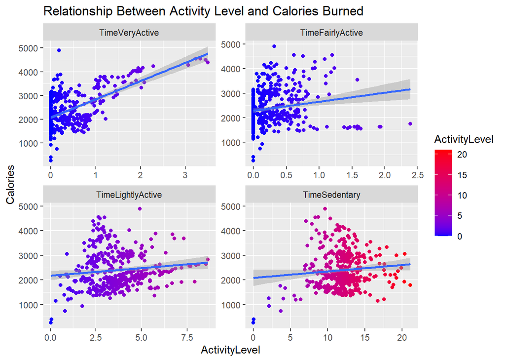

```r
Activitytime.gathered <- Activitytime.gathered %>%
mutate(across(variables, factor, levels = c('TimeVeryActive', 'TimeFairlyActive', 'TimeLightlyActive', 'TimeSedentary')))

ggplot(Activitytime.gathered, aes(x=ActivityLevel, y=Calories, color = ActivityLevel)) + geom_point() + stat_smooth(method=lm) + facet_wrap(~variables, scale = 'free') +  scale_color_gradient(low = "blue", high = "red") + labs(title="Relationship Between Activity Level and Calories Burned")
```

##### This figure shows the relationship between total steps taken and calories burned. There seems to be a positive relationship which reflects the expectation that if the participant took more steps they will burn more calories.

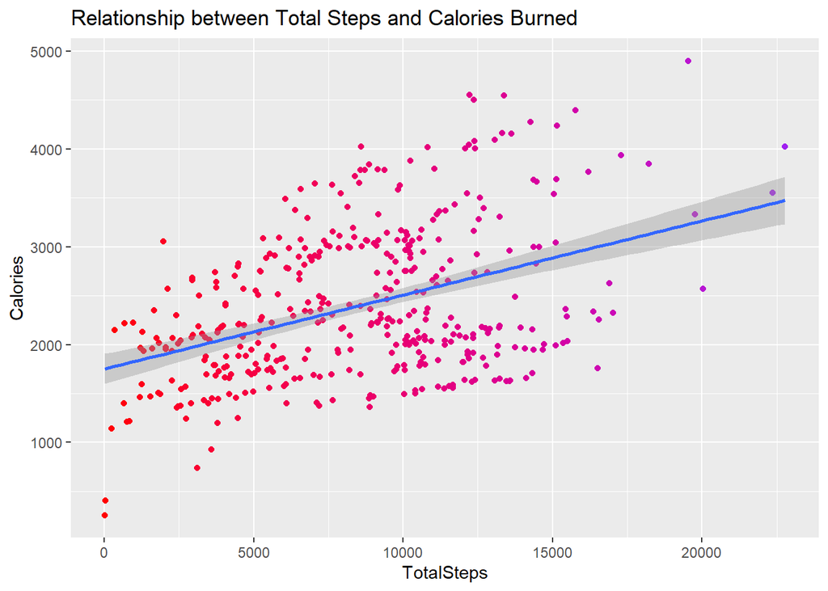

```r
ggplot(daily_userData, aes(x=TotalSteps, y=Calories, color = TotalSteps)) + geom_point() + stat_smooth(method=lm) + scale_color_gradient(low = "red", high = "purple") + labs(title ='Relationship between Total Steps and Calories Burned') +  theme(legend.position="none")
```

```r
daily_userData <- daily_userData %>% mutate(TotalSleep = TotalMinutesAsleep/60)

Sleepquality.gathered <- daily_userData %>% gather(key = 'variables', value = 'ActivityLevel', -TotalSleep, -Id, -Date, -Calories, -TotalSleepRecords, -TotalMinutesAsleep, -TotalTimeInBed, -TotalSteps, -TotalDistance, -TrackerDistance, -LoggedActivitiesDistance, -VeryActiveDistance, -ModeratelyActiveDistance,-LightActiveDistance, -SedentaryActiveDistance, -VeryActiveMinutes, -FairlyActiveMinutes, -LightlyActiveMinutes, -SedentaryMinutes)

head(Sleepquality.gathered)
```

```
##           Id      Date TotalSteps TotalDistance TrackerDistance
## 1 1503960366 4/12/2016      13162          8.50            8.50
## 2 1503960366 4/13/2016      10735          6.97            6.97
## 3 1503960366 4/15/2016       9762          6.28            6.28
## 4 1503960366 4/16/2016      12669          8.16            8.16
## 5 1503960366 4/17/2016       9705          6.48            6.48
## 6 1503960366 4/19/2016      15506          9.88            9.88
##   LoggedActivitiesDistance VeryActiveDistance ModeratelyActiveDistance
## 1                        0               1.88                     0.55
## 2                        0               1.57                     0.69
## 3                        0               2.14                     1.26
## 4                        0               2.71                     0.41
## 5                        0               3.19                     0.78
## 6                        0               3.53                     1.32
##   LightActiveDistance SedentaryActiveDistance VeryActiveMinutes
```

[output cut: 27 more lines]

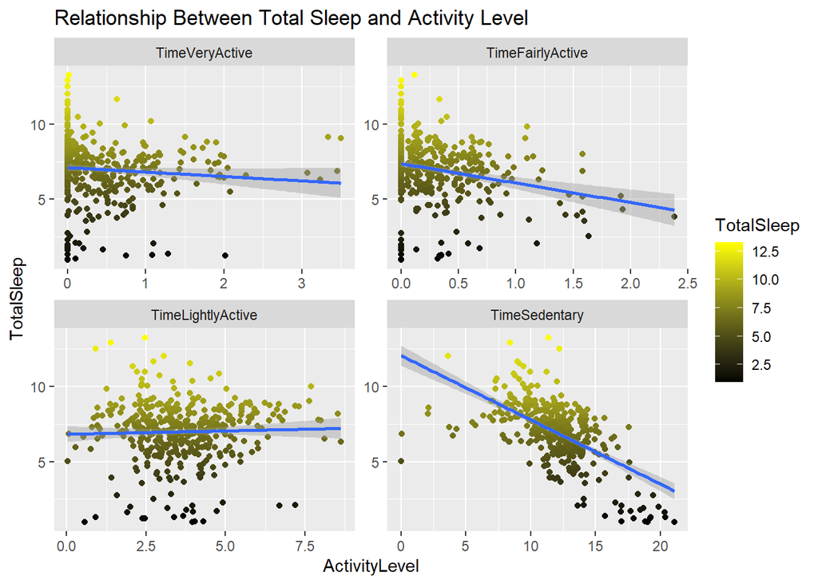

```r
Sleepquality.gathered <- Sleepquality.gathered %>%
  mutate(across(variables, factor, levels = c('TimeVeryActive', 'TimeFairlyActive', 'TimeLightlyActive', 'TimeSedentary')))

ggplot(Sleepquality.gathered, aes(x=ActivityLevel, y= TotalSleep, color = TotalSleep)) + geom_point() + stat_smooth(method=lm) + facet_wrap(~variables, scale = 'free') + scale_color_gradient(low = "black", high = "yellow") + labs(title="Relationship Between Total Sleep and Activity Level")
```

#### Conclusion

From the analysis there are clear trends that gave interesting insights that could be applicable to the marketing strategy for Bellabeat in the global smart device market.

#### Recommendation

1. Recommend users to set goals for total amount of steps taken in a day. Enable notifications to encourage users to meet the goal and if they achieve it, to set a higher goal when they feel ready.
2. Include a function in the Bellabeat app to alert users to try and get at least 30 minutes of moderate activity if data shows that they are often sedentary throughout the day.
3. Have the app notify users with encouraging and motivating messages, especially if they have been sedentary for a extended period of time to motivate activity.
4. Enhance the app to inform users of disruptive sleeping habits, such as irregular sleep schedules or not enough activity.